# SuperKart Project

## Context:

A sales forecast is a prediction of future sales revenue based on historical data, industry trends, and the status of the current sales pipeline. Businesses use the sales forecast to estimate weekly, monthly, quarterly, and annual sales totals. It is extremely important for a company to make an accurate sales forecast as it adds value across an organization and helps the different verticals to chalk out their future course of actions. Forecasting helps an organization to plan its sales operations by regions and provide valuable insights to the supply chain team regarding the procurement of goods and materials. An accurate sales forecast process has many benefits which include improved decision-making about the future and reduction of sales pipeline and forecast risks. Moreover, it helps to reduce the time spent in planning territory coverage and establish benchmarks that can be used to assess trends in the future.

## Objective:

SuperKartKart is an organization which owns a chain of supermarkets and food marts providing a wide range of products. They want to predict the future sales revenue of its different outlets so that they can strategize their sales operation across different tier cities and plan their inventory accordingly. To achieve this purpose, SuperKart has hired a data science firm, shared the sales records of its various outlets for the previous quarter and asked the firm to come up with a suitable model to predict the total sales of the stores for the upcoming quarter.

## Data Description:

The data contains the different attributes of the various products and stores.The detailed data dictionary is given below.

- Product_Id - unique identifier of each product, each identifier having two letters at the beginning followed by a number
- Product_Weight - weight of each product
- Product_Sugar_Content - sugar content of each product like low sugar, regular and no sugar
- Product_Allocated_Area - ratio of the allocated display area of each product to the total display area of all the products in a store
- Product_Type - broad category for each product like meat, snack foods, hard drinks, dairy, canned, soft drinks, health and hygiene, baking goods, breads, breakfast, frozen foods, fruits and vegetables, household, seafood, starchy foods, others
- Product_MRP - maximum retail price of each product
- Store_Id - unique identifier of each store
- Store_Establishment_Year - year in which the store was established
- Store_Size - size of the store depending on sq. feet like high, medium and low
- Store_Location_City_Type - type of city in which the store is located like Tier 1, Tier 2 and Tier 3. Tier 1 consists of cities where the standard of living is comparatively higher than its Tier 2 and Tier 3 counterparts.
- Store_Type - type of store depending on the products that are being sold there like Departmental Store, Supermarket Type 1, Supermarket Type 2 and Food Mart
- Product_Store_Sales_Total - total revenue generated by the sale of that particular product in that particular store

## Importing necessary libraries and data

```python
#Libraries to help with python's structuring
import warnings
warnings.filterwarnings("ignore")

#Libraries helping with reading and manipulating data
import numpy as np
import pandas as pd

#Library to split data
from sklearn.model_selection import train_test_split

#Libraries to help with data visualization
import matplotlib.pyplot as plt
import seaborn as sns

#Removes the limit for the number of displayed columns
pd.set_option("display.max_columns",None)
#sets the limit for the number of displayed rows
pd.set_option("display.max_rows",100)

#Libraries for different ensemble regressors
from sklearn.ensemble import (BaggingRegressor,RandomForestRegressor,AdaBoostRegressor,GradientBoostingRegressor,StackingRegressor,)
from xgboost import XGBRegressor
from sklearn.tree import DecisionTreeRegressor

#Libraries to get different metric scores
from sklearn import metrics
from sklearn.metrics import (confusion_matrix,accuracy_score,precision_score,recall_score,f1_score)

#to tune different models
from sklearn.model_selection import GridSearchCV
```

### Import Dataset

```python
sales=pd.read_csv("SuperKart.csv")
```

```python
data=sales.copy()
```

## Data Overview

- Observations
- Sanity checks

### View the first and last 5 rows of the dataset

```python
data.head()
```

|  | Product_Id | Product_Weight | Product_Sugar_Content | Product_Allocated_Area | Product_Type | Product_MRP | Store_Id | Store_Establishment_Year | Store_Size | Store_Location_City_Type | Store_Type | Product_Store_Sales_Total |
| --- | --- | --- | --- | --- | --- | --- | --- | --- | --- | --- | --- | --- |
| 0 | FD6114 | 12.66 | Low Sugar | 0.027 | Frozen Foods | 117.08 | OUT004 | 2009 | Medium | Tier 2 | Supermarket Type2 | 2842.40 |
| 1 | FD7839 | 16.54 | Low Sugar | 0.144 | Dairy | 171.43 | OUT003 | 1999 | Medium | Tier 1 | Departmental Store | 4830.02 |
| 2 | FD5075 | 14.28 | Regular | 0.031 | Canned | 162.08 | OUT001 | 1987 | High | Tier 2 | Supermarket Type1 | 4130.16 |
| 3 | FD8233 | 12.10 | Low Sugar | 0.112 | Baking Goods | 186.31 | OUT001 | 1987 | High | Tier 2 | Supermarket Type1 | 4132.18 |
| 4 | NC1180 | 9.57 | No Sugar | 0.010 | Health and Hygiene | 123.67 | OUT002 | 1998 | Small | Tier 3 | Food Mart | 2279.36 |

```python
data.tail()
```

|  | Product_Id | Product_Weight | Product_Sugar_Content | Product_Allocated_Area | Product_Type | Product_MRP | Store_Id | Store_Establishment_Year | Store_Size | Store_Location_City_Type | Store_Type | Product_Store_Sales_Total |
| --- | --- | --- | --- | --- | --- | --- | --- | --- | --- | --- | --- | --- |
| 8758 | NC7546 | 14.80 | No Sugar | 0.016 | Health and Hygiene | 140.53 | OUT004 | 2009 | Medium | Tier 2 | Supermarket Type2 | 3806.53 |
| 8759 | NC584 | 14.06 | No Sugar | 0.142 | Household | 144.51 | OUT004 | 2009 | Medium | Tier 2 | Supermarket Type2 | 5020.74 |
| 8760 | NC2471 | 13.48 | No Sugar | 0.017 | Health and Hygiene | 88.58 | OUT001 | 1987 | High | Tier 2 | Supermarket Type1 | 2443.42 |
| 8761 | NC7187 | 13.89 | No Sugar | 0.193 | Household | 168.44 | OUT001 | 1987 | High | Tier 2 | Supermarket Type1 | 4171.82 |
| 8762 | FD306 | 14.73 | Low Sugar | 0.177 | Snack Foods | 224.93 | OUT002 | 1998 | Small | Tier 3 | Food Mart | 2186.08 |

### shape of the dataset

```python
data.shape
```

```
(8763, 12)
```

### datatypes of the columns in the dataset

```python
data.info()
```

```
<class 'pandas.core.frame.DataFrame'>
RangeIndex: 8763 entries, 0 to 8762
Data columns (total 12 columns):
 #   Column                     Non-Null Count  Dtype
---  ------                     --------------  -----
 0   Product_Id                 8763 non-null   object
 1   Product_Weight             8763 non-null   float64
 2   Product_Sugar_Content      8763 non-null   object
 3   Product_Allocated_Area     8763 non-null   float64
 4   Product_Type               8763 non-null   object
 5   Product_MRP                8763 non-null   float64
 6   Store_Id                   8763 non-null   object
 7   Store_Establishment_Year   8763 non-null   int64
 8   Store_Size                 8763 non-null   object
 9   Store_Location_City_Type   8763 non-null   object
 10  Store_Type                 8763 non-null   object
 11  Product_Store_Sales_Total  8763 non-null   float64
dtypes: float64(4), int64(1), object(7)
memory usage: 821.7+ KB
```

- product_weight, product_allocated_area, product_mrp, store_establishment_year,product_store_sales_total are all columns that contain numerical values, the remaining columns are categorical columns that contain objects.
- there are no null values

```python
#checking for duplicate values
data.duplicated().sum()
```

```
0
```

- there are no duplicate values

### statistical summary of the dataset

```python
data.describe().T
```

|  | count | mean | std | min | 25% | 50% | 75% | max |
| --- | --- | --- | --- | --- | --- | --- | --- | --- |
| Product_Weight | 8763.0 | 12.653792 | 2.217320 | 4.000 | 11.150 | 12.660 | 14.180 | 22.000 |
| Product_Allocated_Area | 8763.0 | 0.068786 | 0.048204 | 0.004 | 0.031 | 0.056 | 0.096 | 0.298 |
| Product_MRP | 8763.0 | 147.032539 | 30.694110 | 31.000 | 126.160 | 146.740 | 167.585 | 266.000 |
| Store_Establishment_Year | 8763.0 | 2002.032751 | 8.388381 | 1987.000 | 1998.000 | 2009.000 | 2009.000 | 2009.000 |
| Product_Store_Sales_Total | 8763.0 | 3464.003640 | 1065.630494 | 33.000 | 2761.715 | 3452.340 | 4145.165 | 8000.000 |

```python
data.nunique()
```

```
Product_Id                   8763
Product_Weight               1113
Product_Sugar_Content           4
Product_Allocated_Area        228
Product_Type                   16
Product_MRP                  6100
Store_Id                        4
Store_Establishment_Year        4
Store_Size                      3
Store_Location_City_Type        3
Store_Type                      4
Product_Store_Sales_Total    8668
dtype: int64
```

- product_id can be dropped as it is a unique identifier column and it does not give any significant data to increase prediction power

```python
data.drop(["Product_Id"],axis=1,inplace=True)
```

## Exploratory Data Analysis (EDA)

- EDA is an important part of any project involving data.
- It is important to investigate and understand the data better before building a model with it.
- A few questions have been mentioned below which will help you approach the analysis in the right manner and generate insights from the data.
- A thorough analysis of the data, in addition to the questions mentioned below, should be done.

**Questions**

- Different varieties of products are available at stores. A store needs to plan its inventory appropriately which is well aligned to the supply and demand characteristics. Which product type is contributing the most to the revenue of the company (SuperKart)?
- Location may have a high impact on the revenue of a store. Find out the type of stores and locations that are having a high impact on the revenue of the company.
- Nowadays many customers prefer products that have low sugar content in them. How many items have been sold in each of the 16 product types that have low sugar content in them?
- Which product type has been sold the most number of times in each of the stores? Which product type is contributing the most to the revenue of the individual stores?
- There are some stores of a company that generally sell only premium items having higher prices than others. Which store has sold more costly goods than others?

```python
# function to plot a boxplot and a histogram along the same scale.


def histogram_boxplot(data, feature, figsize=(12, 7), kde=False, bins=None):
    """
    Boxplot and histogram combined

    data: dataframe
    feature: dataframe column
    figsize: size of figure (default (12,7))
    kde: whether to the show density curve (default False)
    bins: number of bins for histogram (default None)
    """
    f2, (ax_box2, ax_hist2) = plt.subplots(
        nrows=2,  # Number of rows of the subplot grid= 2
        sharex=True,  # x-axis will be shared among all subplots
        gridspec_kw={"height_ratios": (0.25, 0.75)},
        figsize=figsize,
    )  # creating the 2 subplots
    sns.boxplot(
        data=data, x=feature, ax=ax_box2, showmeans=True, color="violet"
    )  # boxplot will be created and a triangle will indicate the mean value of the column
    sns.histplot(
        data=data, x=feature, kde=kde, ax=ax_hist2, bins=bins
    ) if bins else sns.histplot(
        data=data, x=feature, kde=kde, ax=ax_hist2
    )  # For histogram
    ax_hist2.axvline(
        data[feature].mean(), color="green", linestyle="--"
    )  # Add mean to the histogram
    ax_hist2.axvline(
        data[feature].median(), color="black", linestyle="-"
    )  # Add median to the histogram
```

```python
# function to create labeled barplots


def labeled_barplot(data, feature, perc=False, n=None):
    """
    Barplot with percentage at the top

    data: dataframe
    feature: dataframe column
    perc: whether to display percentages instead of count (default is False)
    n: displays the top n category levels (default is None, i.e., display all levels)
    """

    total = len(data[feature])  # length of the column
    count = data[feature].nunique()
    if n is None:
        plt.figure(figsize=(count + 2, 6))
    else:
        plt.figure(figsize=(n + 2, 6))

    plt.xticks(rotation=90, fontsize=15)
    ax = sns.countplot(
        data=data,
        x=feature,
        palette="Paired",
        order=data[feature].value_counts().index[:n],
    )

    for p in ax.patches:
        if perc == True:
            label = "{:.1f}%".format(
                100 * p.get_height() / total
            )  # percentage of each class of the category
        else:
            label = p.get_height()  # count of each level of the category

        x = p.get_x() + p.get_width() / 2  # width of the plot
        y = p.get_height()  # height of the plot

        ax.annotate(
            label,
            (x, y),
            ha="center",
            va="center",
            size=12,
            xytext=(0, 5),
            textcoords="offset points",
        )  # annotate the percentage

    plt.show()  # show the plot
```

### Univariate Analysis

#### product_weight

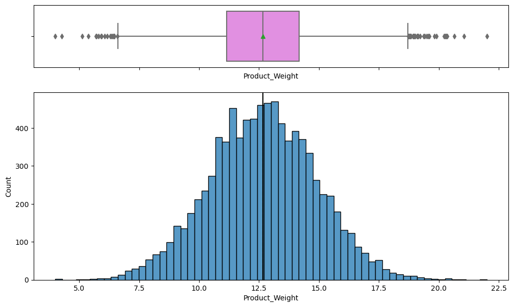

```python
histogram_boxplot(data,"Product_Weight")
```

#### product_mrp

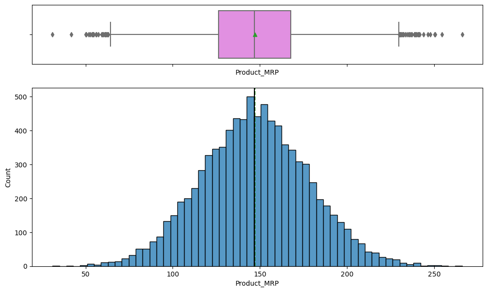

```python
histogram_boxplot(data,"Product_MRP")
```

#### product_store_sales_total

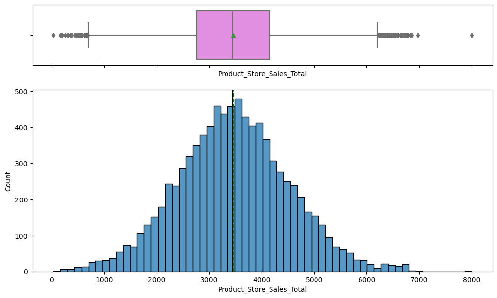

```python
histogram_boxplot(data,"Product_Store_Sales_Total")
```

- Mean is a bit greater than median with both hovering around 3500
- Distribution is skewed to the right

#### product_sugar_content

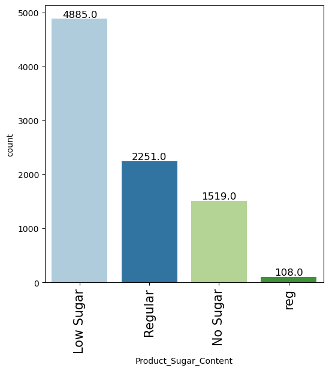

```python
labeled_barplot(data,"Product_Sugar_Content")
```

- Low sugar content products contribute to more than half of the total sales of all the products with 4885 products

#### product_type

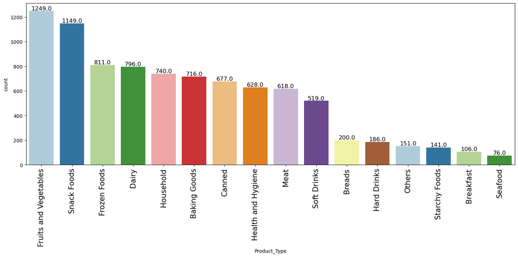

```python
labeled_barplot(data,"Product_Type")
```

- Fruits and vegetables have the most amount of products sold in the supermarket with 1249 total products sold
- Snack foods come in at 2nd with over 1000 products sold

#### store_type

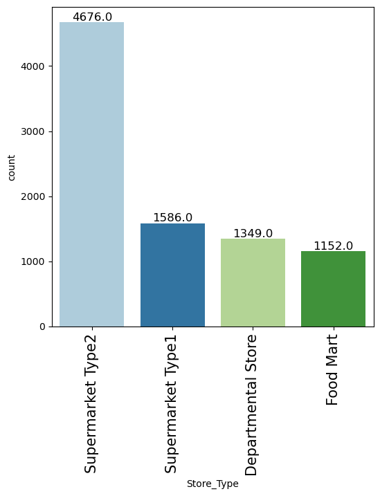

```python
labeled_barplot(data,"Store_Type")
```

- Supermarket Type2 generally have more stores than Supermarket Type1
- Food Mart have the lowest amount of stores

#### store_location_city_type

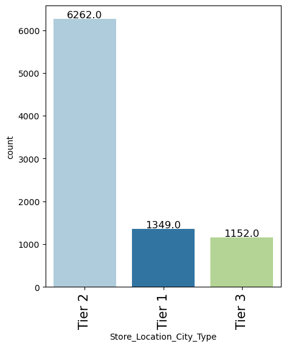

```python
labeled_barplot(data,"Store_Location_City_Type")
```

#### store_size

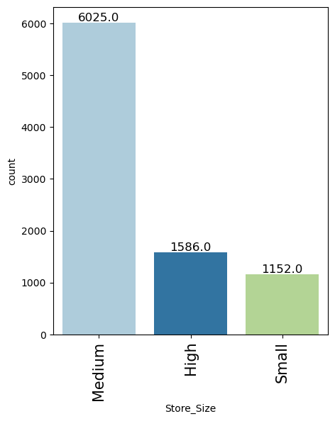

```python
labeled_barplot(data, "Store_Size")
```

### Bivariate Analysis

#### heatmap of numerical columns

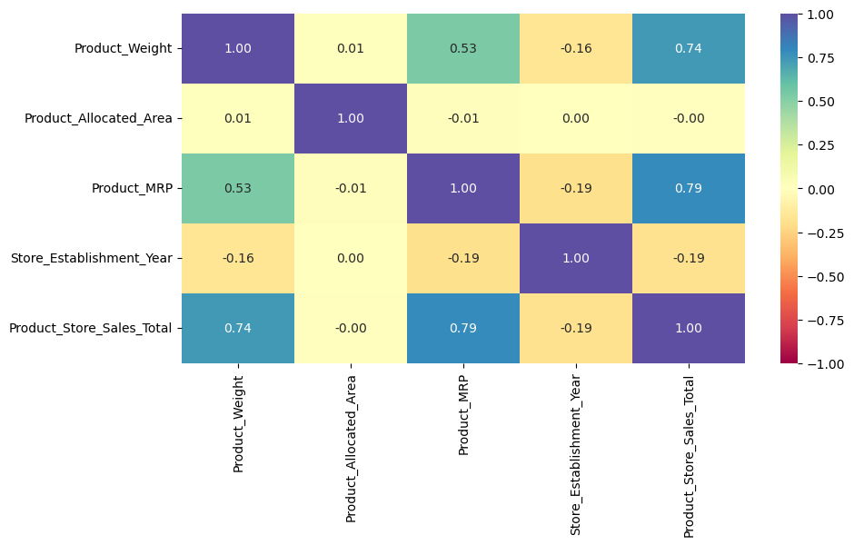

```python
cols_list=data.select_dtypes(include=np.number).columns.tolist()

plt.figure(figsize=(10,5))
sns.heatmap(data[cols_list].corr(),annot=True,vmin=-1,vmax=1,fmt=".2f",cmap="Spectral")
plt.show()
```

- The retail price of the product and the sales of the product have the highest correlation
- The weight and the total sales of the product have the second highest correlation
- The retail price of the product and the weight of the product are also have a strong correlation

```python
### function to plot distributions wrt target


def distribution_plot_wrt_target(data, predictor, target):

    fig, axs = plt.subplots(2, 2, figsize=(12, 10))

    target_uniq = data[target].unique()


    axs[0, 0].set_title("Distribution of target for target=" + str(target_uniq[0]))
    sns.histplot(
        data=data[data[target] == target_uniq[0]],
        x=predictor,
        kde=True,
        ax=axs[0, 0],
        color="teal",
        stat="density",
    )

    axs[0, 1].set_title("Distribution of target for target=" + str(target_uniq[1]))
    sns.histplot(
        data=data[data[target] == target_uniq[1]],
        x=predictor,
        kde=True,
        ax=axs[0, 1],
        color="orange",
        stat="density",
    )

    axs[1, 0].set_title("Boxplot w.r.t target")
    plt.xticks(rotation=90)
    sns.boxplot(data=data, x=target, y=predictor, ax=axs[1, 0], palette="gist_rainbow")

    axs[1, 1].set_title("Boxplot (without outliers) w.r.t target")
    plt.xticks(rotation=90)
    sns.boxplot(
        data=data,
        x=target,
        y=predictor,
        ax=axs[1, 1],
        showfliers=False,
        palette="gist_rainbow",
    )

    plt.tight_layout()
    plt.show()
```

```python
def stacked_barplot(data, predictor, target):
    """
    Print the category counts and plot a stacked bar chart

    data: dataframe
    predictor: independent variable
    target: target variable
    """
    count = data[predictor].nunique()
    sorter = data[target].value_counts().index[-1]
    tab1 = pd.crosstab(data[predictor], data[target], margins=True).sort_values(
        by=sorter, ascending=False
    )
    print(tab1)
    print("-" * 120)
    tab = pd.crosstab(data[predictor], data[target], normalize="index").sort_values(
        by=sorter, ascending=False
    )
    tab.plot(kind="bar", stacked=True, figsize=(count + 5, 5))
    plt.legend(
        loc="lower left", frameon=False,
    )
    plt.legend(loc="upper left", bbox_to_anchor=(1, 1))
    plt.show()
```

#### total sales of each product vs the city the store is in

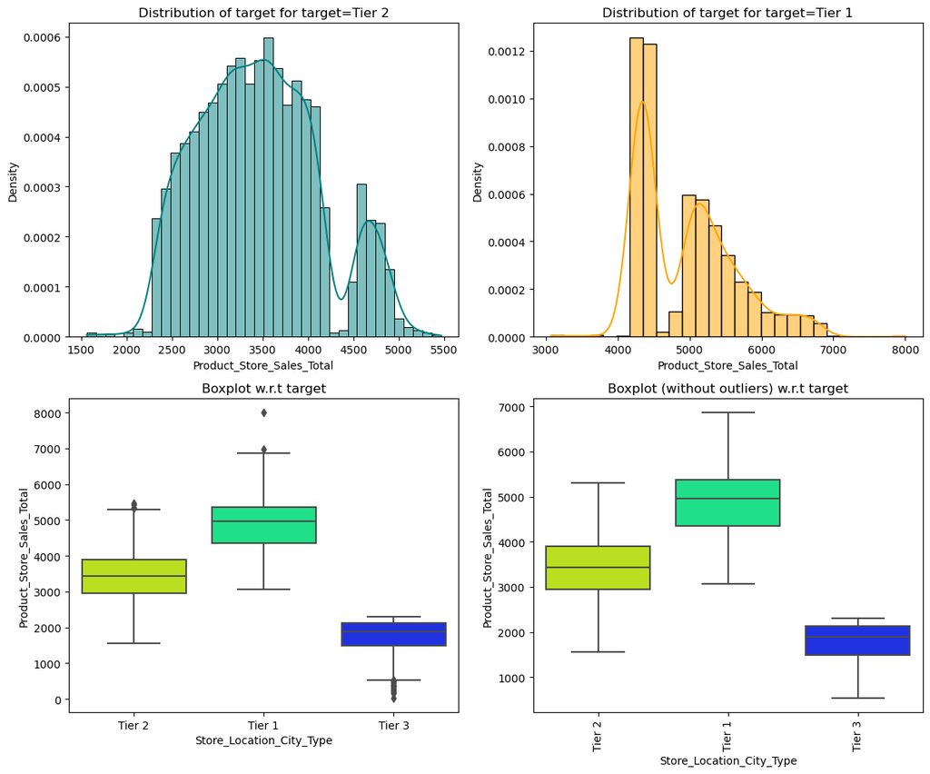

```python
distribution_plot_wrt_target(data,"Product_Store_Sales_Total","Store_Location_City_Type")
```

- Tier 1 cities generally have the highest number of total sales while tier 3 have the lowest amount of total sales

#### total sales of each product vs the type of store

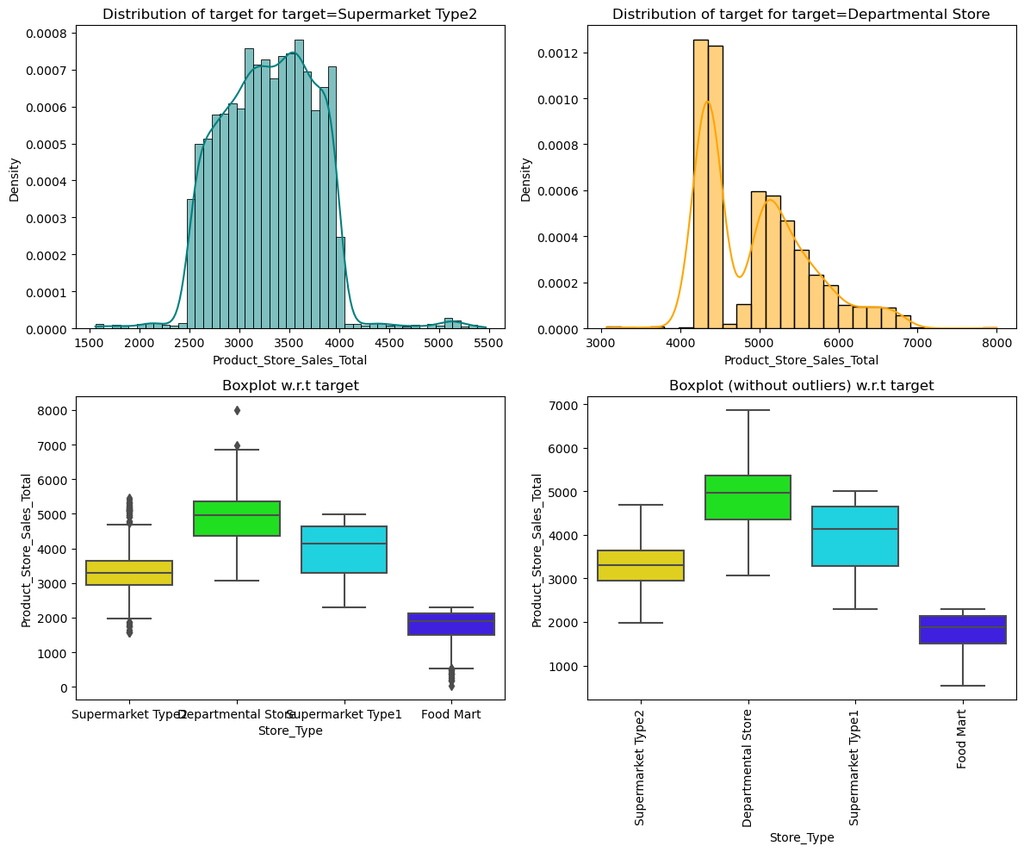

```python
distribution_plot_wrt_target(data,"Product_Store_Sales_Total","Store_Type")
```

- Departmental stores have the highest amount of sales even with the highest priced products while food mart have the lowest amount of sales with the lowest price for products out of all the stores

#### the retail price of each product vs the type of store

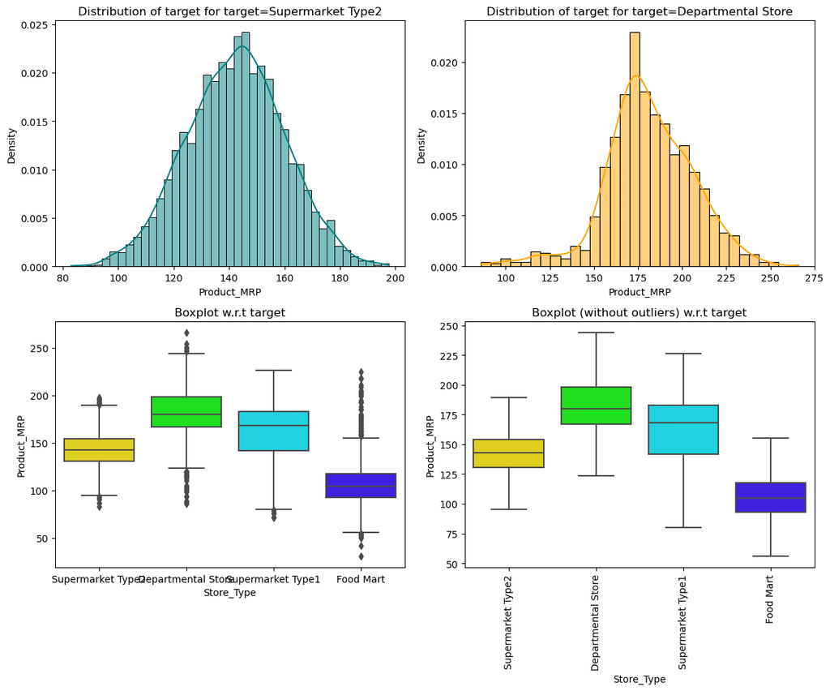

```python
distribution_plot_wrt_target(data,"Product_MRP","Store_Type")
```

- departmental stores have the highest priced products while food mart's products were generally priced lower
- supermarket type 2 followed a central distribution while the departmental stores were following a right skewed distribution

#### the retail price of each product vs the city the store is in

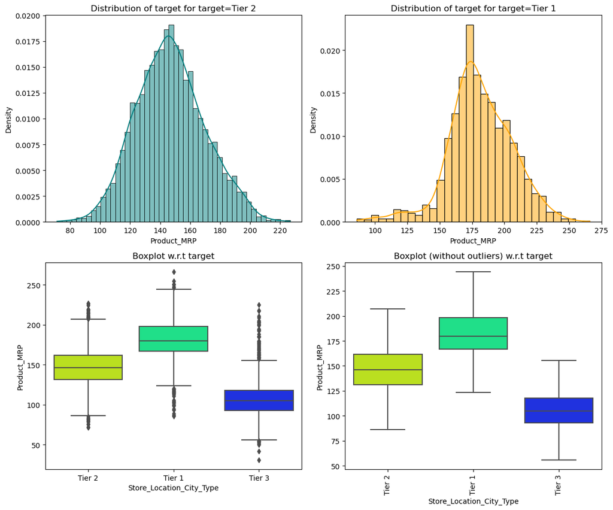

```python
distribution_plot_wrt_target(data,"Product_MRP","Store_Location_City_Type")
```

- Tier 1 products have the highest priced products with their products having a median of a littel bit above 175 dollars
- Tier 3 got the lowest priced products with their products having a median a bit over 100 dollars to give an estimate

#### the store the city is in vs the type of product that is being sold

```
Product_Type              Baking Goods  Breads  Breakfast  Canned  Dairy  \
Store_Location_City_Type
All                                716     200        106     677    796
Tier 2                             521     143         72     499    547
Tier 1                              99      34         19      90    145
Tier 3                              96      23         15      88    104

Product_Type              Frozen Foods  Fruits and Vegetables  Hard Drinks  \
Store_Location_City_Type
All                                811                   1249          186
Tier 2                             588                    899          133
Tier 1                             122                    182           23
Tier 3                             101                    168           30

Product_Type              Health and Hygiene  Household  Meat  Others  \
Store_Location_City_Type
All                                      628        740   618     151
Tier 2                                   448        533   425     100
Tier 1                                    89        107   106      32
Tier 3                                    91        100    87      19

Product_Type              Seafood  Snack Foods  Soft Drinks  Starchy Foods  \
Store_Location_City_Type
All                            76         1149          519            141
Tier 2                         53          817          383            101
Tier 1                         13          186           74             28
Tier 3                         10          146           62             12

Product_Type               All
Store_Location_City_Type
All                       8763
Tier 2                    6262
Tier 1                    1349
Tier 3                    1152
------------------------------------------------------------------------------------------------------------------------
```

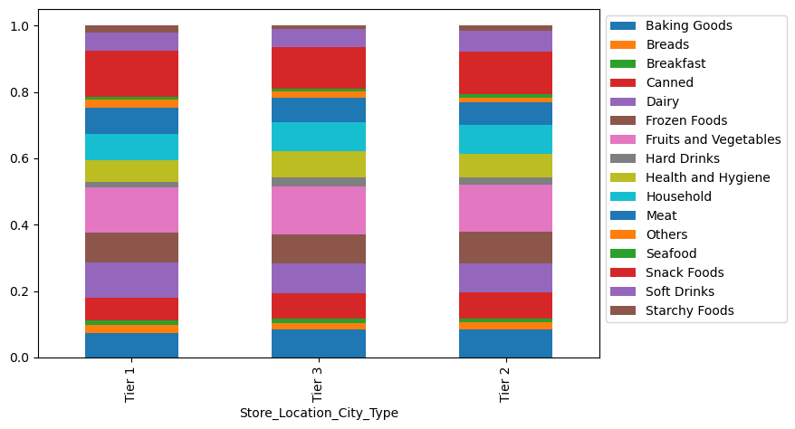

```python
stacked_barplot(data,"Store_Location_City_Type","Product_Type")
```

#### the city the store is in vs the size of the store

```
Store_Size                High  Medium  Small   All
Store_Location_City_Type
Tier 3                       0       0   1152  1152
All                       1586    6025   1152  8763
Tier 1                       0    1349      0  1349
Tier 2                    1586    4676      0  6262
------------------------------------------------------------------------------------------------------------------------
```

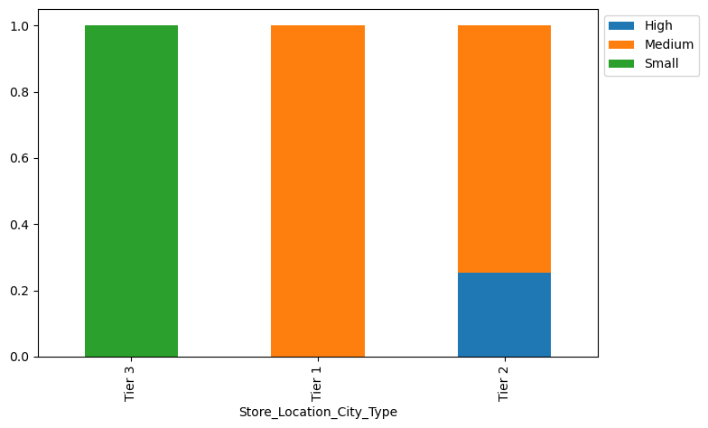

```python
stacked_barplot(data,"Store_Location_City_Type","Store_Size")
```

#### the type of store vs the size of the store

```
Store_Size          High  Medium  Small   All
Store_Type
Food Mart              0       0   1152  1152
All                 1586    6025   1152  8763
Departmental Store     0    1349      0  1349
Supermarket Type1   1586       0      0  1586
Supermarket Type2      0    4676      0  4676
------------------------------------------------------------------------------------------------------------------------
```

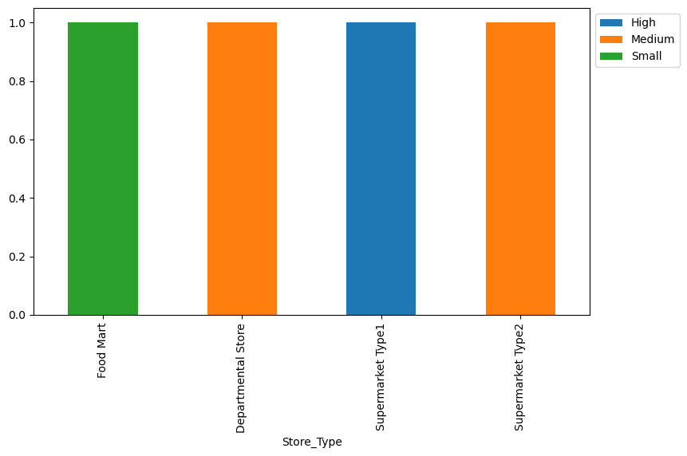

```python
stacked_barplot(data,"Store_Type","Store_Size")
```

- the majority of the stores are medium sized, with 100% of the departmetnal stores and type 2 supermarkets being medium sized in terms of its square feet
- type 1 supermarkets is the only type of store to have a high square feet with 100% of its stores having a high square feet,while the food mart is the only store with a small square feet with all of its stores contatining a small square feet

## Data Preprocessing

- Missing value treatment (if needed)
- Outlier detection and treatment (if needed)
- Preparing data for modeling
- Any other preprocessing steps (if needed)

#### outlier check

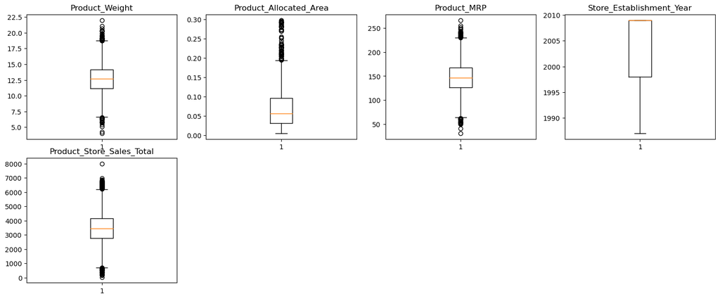

```python
# outlier detection using boxplot
numeric_columns=data.select_dtypes(include=np.number).columns.tolist()

plt.figure(figsize=(15,12))

for i, variable in enumerate(numeric_columns):
    plt.subplot(4,4,i+1)
    plt.boxplot(data[variable], whis=1.5)
    plt.tight_layout()
    plt.title(variable)

plt.show()
```

- there are plenty of outliers, but we will not treat them as they might represent real values and there needs to be variation in our model

```python
x=data.drop("Product_Store_Sales_Total", axis=1)
Y=data["Product_Store_Sales_Total"]

x=pd.get_dummies(x,drop_first=True)
```

```python
#splitting data into train and test sets in 70:30 ratio
x_train,x_test,Y_train,Y_test=train_test_split(x,Y,test_size=0.30,random_state=1,shuffle=True)
```

```python
x_train.shape,x_test.shape
```

```
((6134, 32), (2629, 32))
```

## Feature Engineering

**A store which has been in the business for a long duration is more trustworthy than the newly established ones. On the other hand, older stores may sometimes lack infrastructure if proper attention is not given. So let us calculate the current age of the store and incorporate that in our model.**

```python
import datetime
current_date=datetime.date.today()
data["age"]=current_date.year-data["Store_Establishment_Year"]
```

**We have 16 different product types in our dataset. So let us make two broad categories, perishables and non perishables, in order to reduce the number of product types.**

```python
perishables = [
    "Dairy",
    "Meat",
    "Fruits and Vegetables",
    "Breakfast",
    "Breads",
    "Seafood",
]
```

```python
def change(x):
    if x in perishables:
        return "Perishables"
    else:
        return "Non Perishables"


data.Product_Type.apply(change)
```

```
0       Non Perishables
1           Perishables
2       Non Perishables
3       Non Perishables
4       Non Perishables
             ...
8758    Non Perishables
8759    Non Perishables
8760    Non Perishables
8761    Non Perishables
8762    Non Perishables
Name: Product_Type, Length: 8763, dtype: object
```

```python
change1 = []
for i in range(0, len(data)):
    if data.Product_Type[i] in perishables:
        change1.append("Perishables")
    else:
        change1.append("Non Perishables")
```

## Building bagging and boosting models

```python
#function to compute adjusted R-squared
def adj_r2_score(predictors,targets,predictions):
    r2=r2_score(targets,predictions)
    n=predictors.shape[0]
    k=predictors.shape[1]
    return 1-((1-r2)*(n-1)/(n-k-1))

#function to compute MAPE
def mape_score(targets,predictions):
    return np.mean(np.abs(targets-predictions)/targets)*100

#function to compute different metrics to check performance of a regression
def model_performance_regression(model,predictors,target):
    """
    Function to compute diffferent metrics to check regression model performance

    model:regressor
    predictors:independent variables
    target:dependent variable
    """

    #predicting using the independent variables
    pred=model.predict(predictors)

    r2=r2_score(target,pred) #to compute R-squared
    adjr2=adj_r2_score(predictors,target,pred) #to compute adjusted R-squared
    rmse=np.sqrt(mean_squared_error(target,pred)) #to compute MAE
    mae=mean_absolute_error(target,pred) #to compute MAE
    mape=mape_score(target,pred) #to compute MAPE

    #creating a dataframe of metrics
    df_perf=pd.DataFrame(
        {
            "RMSE": rmse,
            "MAE": mae,
            "R-squared": r2,
            "Adj. R-squared": adjr2,
            "MAPE": mape,
        },
        index=[0],
    )

    return df_perf
```

```python
## Function to calculate r2_score and RMSE on train and test data
def get_model_score(model,flag=True):
    '''
    model:classifier to predict values for x

    '''

    #defining an empty list to store train and test results
    score_list=[]

    pred_train=model.predict(x_train)
    pred_test=model.predict(x_test)

    train_r2=metrics.r2_score(Y_train,pred_train)
    test_r2=metrics.r2_score(Y_test,pred_test)
    train_rmse=np.sqrt(metrics.mean_squared_error(Y_train,pred_train))
    test_rmse=np.sqrt(metrics.mean_squared_error(Y_test,pred_test))

    #adding all scores in the list
    score_list.extend((train_r2,test_r2,train_rmse,test_rmse))

    #if the flag is set to True then only the following print statements will be displayed, the default value is True
    if flag==True:
        print("R-square on training set:",metrics.r2_score(Y_train,pred_train))
        print("R-square on test set:",metrics.r2_score(Y_test,pred_test))
        print("RMSE on training set:",np.sqrt(metrics.mean_squared_error(Y_train,pred_train)))
        print("RMSE on test set:",np.sqrt(metrics.mean_squared_error(Y_test,pred_test)))

    #Returning the list with train and test scores
    return score_list
```

## Bagging-Model Building

### Decision Tree Model

```python
dtree=DecisionTreeRegressor(random_state=1)
dtree.fit(x_train,Y_train)
```

```
DecisionTreeRegressor(random_state=1)
```

```python
from sklearn.metrics import r2_score,mean_squared_error,mean_absolute_error
```

```python
dtree_model_train_perf=model_performance_regression(dtree,x_train, Y_train)
print("Training performance \n", dtree_model_train_perf)
```

```
Training performance
    RMSE  MAE  R-squared  Adj. R-squared  MAPE
0   0.0  0.0        1.0             1.0   0.0
```

```python
dtree_model_test_perf=model_performance_regression(dtree,x_test,Y_test)
print("Testing performance \n",dtree_model_test_perf)
```

```
Testing performance
          RMSE         MAE  R-squared  Adj. R-squared      MAPE
0  380.764206  129.898505   0.873307        0.871745  5.560926
```

- the decision tree model with the default parameters is overfitting the data
- decision Tree has to be hypertuned in order to give a better performance

### Bagging Regressor Model

```python
bagging_regressor=BaggingRegressor(random_state=1)
bagging_regressor.fit(x_train,Y_train)
```

```
BaggingRegressor(random_state=1)
```

```python
bagging_regressor_model_train_perf=model_performance_regression(bagging_regressor,x_train,Y_train)
print("Training performance \n", bagging_regressor_model_train_perf)
```

```
Training performance
          RMSE        MAE  R-squared  Adj. R-squared     MAPE
0  118.635758  44.811827   0.987561        0.987496  1.60865
```

```python
bagging_regressor_model_test_perf=model_performance_regression(bagging_regressor,x_test,Y_test)
print("Testing performance \n",bagging_regressor_model_test_perf)
```

```
Testing performance
          RMSE         MAE  R-squared  Adj. R-squared      MAPE
0  307.062513  119.273693   0.917606        0.916591  5.086928
```

- Training set is overfitting the testing data
- hyperparameter tuning needs to be done

### Random Forest Model

```python
rf_estimator=RandomForestRegressor(random_state=1)
rf_estimator.fit(x_train,Y_train)
```

```
RandomForestRegressor(random_state=1)
```

```python
rf_estimator_model_train_perf= model_performance_regression(rf_estimator, x_train, Y_train)
print("Training performance \n",rf_estimator_model_train_perf)
```

```
Training performance
          RMSE        MAE  R-squared  Adj. R-squared      MAPE
0  103.579909  39.468334   0.990518        0.990468  1.394348
```

```python
rf_estimator_model_test_perf=model_performance_regression(rf_estimator, x_test, Y_test)
print("testing performance \n", rf_estimator_model_test_perf)
```

```
testing performance
          RMSE         MAE  R-squared  Adj. R-squared     MAPE
0  294.485128  111.512945   0.924218        0.923284  4.99139
```

- the base random forest model has good pewrformance but it is not generalizing when it comes to the testing
- tuning might help it generalizing more of the testing data

## Boosting-Model Building

### Adaboost Regressor

```python
ab_regressor=AdaBoostRegressor(random_state=1)
ab_regressor.fit(x_train,Y_train)
```

```
AdaBoostRegressor(random_state=1)
```

```python
ab_regressor_model_train_perf=model_performance_regression(ab_regressor,x_train,Y_train)
print("Training Performance \n", ab_regressor_model_train_perf)
```

```
Training Performance
          RMSE         MAE  R-squared  Adj. R-squared       MAPE
0  518.669096  415.459639   0.762246        0.760999  14.083721
```

```python
ab_regressor_model_test_perf=model_performance_regression(ab_regressor,x_test,Y_test)
print("Testing Performance \n", ab_regressor_model_test_perf)
```

```
Testing Performance
          RMSE        MAE  R-squared  Adj. R-squared       MAPE
0  538.310826  431.46913   0.746775        0.743654  16.478161
```

- Model generalized well on training set, but r-squared score should be higher
- hyperparameter tuning should increase the performance

### Gradient Boosting Regressor

```python
gb_estimator=GradientBoostingRegressor(random_state=1)
gb_estimator.fit(x_train,Y_train)
```

```
GradientBoostingRegressor(random_state=1)
```

```python
gb_estimator_model_train_perf=model_performance_regression(gb_estimator, x_train, Y_train)
print("Training performance \n", gb_estimator_model_train_perf)
```

```
Training performance
          RMSE         MAE  R-squared  Adj. R-squared      MAPE
0  291.490433  141.389962   0.924908        0.924514  5.084413
```

```python
gb_estimator_model_test_perf=model_performance_regression(gb_estimator, x_test, Y_test)
print("Testing performance \n", gb_estimator_model_test_perf)
```

```
Testing performance
         RMSE         MAE  R-squared  Adj. R-squared      MAPE
0  322.28413  155.544186   0.909235        0.908116  6.624532
```

- gradient boosting model is generalizing well
- performance is good but not as good as random forest

### xgboost regressor

```python
xgb_estimator=XGBRegressor(random_state=1, verbosity=0)
xgb_estimator.fit(x_train,Y_train)
```

```
XGBRegressor(base_score=None, booster=None, callbacks=None,
             colsample_bylevel=None, colsample_bynode=None,
             colsample_bytree=None, device=None, early_stopping_rounds=None,
             enable_categorical=False, eval_metric=None, feature_types=None,
             gamma=None, grow_policy=None, importance_type=None,
             interaction_constraints=None, learning_rate=None, max_bin=None,
             max_cat_threshold=None, max_cat_to_onehot=None,
             max_delta_step=None, max_depth=None, max_leaves=None,
             min_child_weight=None, missing=nan, monotone_constraints=None,
             multi_strategy=None, n_estimators=None, n_jobs=None,
             num_parallel_tree=None, random_state=1, ...)
```

```python
xgb_estimator_model_train_perf=model_performance_regression(xgb_estimator, x_train, Y_train)
print("training performance \n",xgb_estimator_model_train_perf)
```

```
training performance
         RMSE        MAE  R-squared  Adj. R-squared     MAPE
0  116.12006  57.210877   0.988083        0.988021  1.93252
```

```python
xgb_estimator_model_test_perf=model_performance_regression(xgb_estimator, x_test,Y_test)
print("testing performance \n",xgb_estimator_model_test_perf)
```

```
testing performance
          RMSE         MAE  R-squared  Adj. R-squared      MAPE
0  310.592446  138.111121   0.915701        0.914662  5.631813
```

- xgboost giving very high results for the model but not as high as random forest
- Might be overfitting as the testing set is tanking

## Will tuning the hyperparameters improve the model performance?

### Decision Tree Tuning

```python
dtree_tuned=DecisionTreeRegressor(random_state=1)

#Grid of parameters to choose from
parameters = { 'max_depth': list(np.arange(2,20)) + [None],
               'min_samples_leaf': [1,3,5,7,10],
               'max_leaf_nodes' : [2,3,5,10,15] + [None],
               'min_impurity_decrease': [0.001,0.01,0.1,0.0]
             }

#Type of scoring used to compare parameter combinations
scorer=metrics.make_scorer(metrics.r2_score)

#Run the grid search
grid_obj = GridSearchCV(dtree_tuned,parameters,scoring=scorer,cv=5)
grid_obj=grid_obj.fit(x_train,Y_train)

#set the clf to the best combination of parameters
dtree_tuned = grid_obj.best_estimator_

#Fit the best algorithm to the data
dtree_tuned.fit(x_train, Y_train)
```

```
DecisionTreeRegressor(max_depth=9, min_impurity_decrease=0.001,
                      min_samples_leaf=7, random_state=1)
```

```python
dtree_tuned_model_train_perf= model_performance_regression(dtree_tuned,x_train,Y_train)
print("Training performance \n",dtree_tuned_model_train_perf)
```

```
Training performance
          RMSE         MAE  R-squared  Adj. R-squared      MAPE
0  258.229224  122.736094   0.941067        0.940758  4.217715
```

```python
dtree_tuned_model_test_perf=model_performance_regression(dtree_tuned, x_test, Y_test)
print("Testing performance \n",dtree_tuned_model_test_perf)
```

```
Testing performance
          RMSE         MAE  R-squared  Adj. R-squared      MAPE
0  310.006452  146.768554   0.916019        0.914984  6.355626
```

- overfitting dropped tremendously after tuning

#### plotting feature importance of each variable

```python
print(pd.DataFrame(dtree_tuned.feature_importances_, columns=["Imp"], index=x_train.columns).sort_values(by="Imp", ascending=False))
```

```
                                         Imp
Product_MRP                         0.482639
Store_Location_City_Type_Tier 3     0.144757
Store_Id_OUT004                     0.126198
Store_Id_OUT002                     0.090874
Product_Weight                      0.089694
Store_Id_OUT003                     0.059425
Store_Location_City_Type_Tier 2     0.003168
Product_Allocated_Area              0.000948
Store_Size_Medium                   0.000600
Store_Establishment_Year            0.000438
Product_Type_Household              0.000358
Product_Type_Fruits and Vegetables  0.000238
Store_Type_Supermarket Type2        0.000178
Store_Type_Supermarket Type1        0.000114
Product_Type_Canned                 0.000093
Product_Type_Health and Hygiene     0.000078
Product_Type_Frozen Foods           0.000065
Product_Type_Snack Foods            0.000059
Product_Type_Soft Drinks            0.000026
Product_Type_Dairy                  0.000026
Product_Sugar_Content_Regular       0.000023
Product_Sugar_Content_reg           0.000000
Store_Type_Food Mart                0.000000
Product_Sugar_Content_No Sugar      0.000000
Store_Size_Small                    0.000000
Product_Type_Hard Drinks            0.000000
Product_Type_Breads                 0.000000
Product_Type_Breakfast              0.000000
Product_Type_Starchy Foods          0.000000
Product_Type_Seafood                0.000000
Product_Type_Others                 0.000000
Product_Type_Meat                   0.000000
```

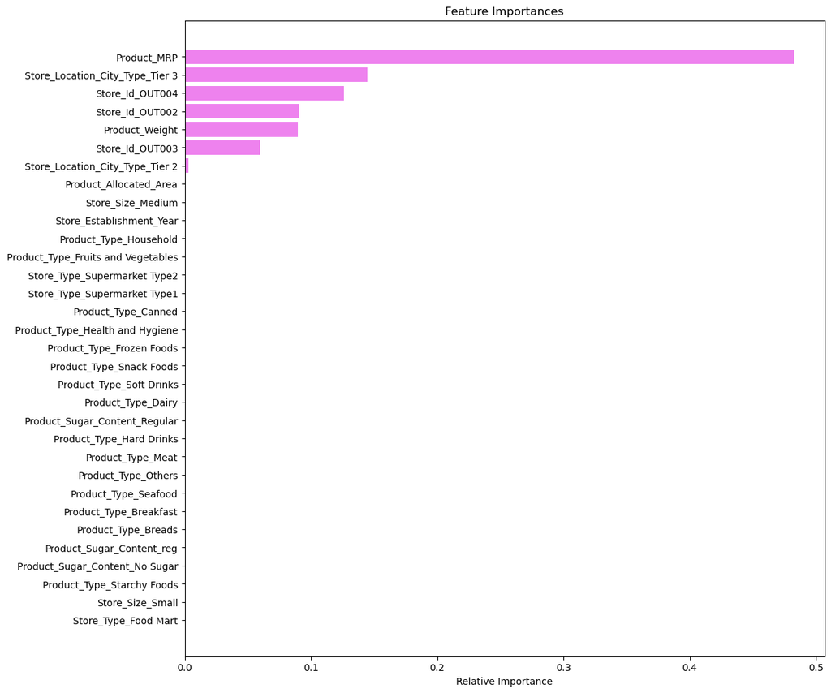

```python
feature_names= x_train.columns
importances=dtree_tuned.feature_importances_
indices=np.argsort(importances)

plt.figure(figsize=(12,12))
plt.title("Feature Importances")
plt.barh(range(len(indices)),importances[indices], color='violet', align='center')
plt.yticks(range(len(indices)), [feature_names[i] for i in indices])
plt.xlabel('Relative Importance')
plt.show()
```

### Bagging Tuning

```python
bagging_estimator_tuned= BaggingRegressor(random_state=1)

#Grid of parameters to choose from
parameters= {
                "max_samples":[0.7,0.8,0.9],
                "max_features": [0.7,0.8,0.9],
                "n_estimators": [90,120,110]
}

#type of scoring used to compare pararmeter combinations
r2_scorer=metrics.make_scorer(metrics.r2_score)

#Run the grid search
grid_obj=GridSearchCV(bagging_estimator_tuned, parameters, scoring=r2_scorer, cv=5)
grid_obj=grid_obj.fit(x_train,Y_train)

#set clf to best combination of parameters
bagging_estimator_tuned=grid_obj.best_estimator_

#Fit the best algorithm to the data
bagging_estimator_tuned.fit(x_train,Y_train)
```

```
BaggingRegressor(max_features=0.9, max_samples=0.7, n_estimators=110,
                 random_state=1)
```

```python
bagging_regressor_tuned_train_model_perf=model_performance_regression(bagging_estimator_tuned,x_train,Y_train)
print("Train performance \n",bagging_regressor_tuned_train_model_perf)
```

```
Train performance
          RMSE        MAE  R-squared  Adj. R-squared      MAPE
0  147.647087  78.397256   0.980734        0.980633  2.793973
```

```python
bagging_regressor_tuned_test_model_perf=model_performance_regression(bagging_estimator_tuned,x_test,Y_test)
print("Testing performance \n", bagging_regressor_tuned_test_model_perf)
```

```
Testing performance
          RMSE         MAE  R-squared  Adj. R-squared      MAPE
0  308.178734  160.786777   0.917006        0.915983  6.858755
```

- performance remains the same after tuning

### Random Forest Tuning

```python
rf_tuned=RandomForestRegressor(random_state=1)

#Grid of parameters to choose from
parameters={
                "max_depth":[4,6,8,10,None],
                "max_features":["sqrt","log2",None],
                "n_estimators":[80,90,100,110,120]
}

#type of scoring used to combine parameter cobinations
scorer=metrics.make_scorer(metrics.r2_score)

#Running the grid search
grid_obj=GridSearchCV(rf_tuned, parameters,scoring=scorer,cv=5)
grid_obj=grid_obj.fit(x_train,Y_train)

#setting the clf to the best combination of parameters
rf_tuned=grid_obj.best_estimator_

#Fit the best algorithm to the data
rf_tuned.fit(x_train,Y_train)
```

```
RandomForestRegressor(max_depth=10, max_features=None, n_estimators=120,
                      random_state=1)
```

```python
rf_tuned_model_train_perf=model_performance_regression(rf_tuned,x_train,Y_train)
print("training Performance \n",rf_tuned_model_train_perf)
```

```
training Performance
          RMSE        MAE  R-squared  Adj. R-squared      MAPE
0  182.444629  75.097417   0.970582        0.970428  2.512823
```

```python
rf_tuned_model_test_perf=model_performance_regression(rf_tuned,x_test,Y_test)
print("testing performance \n",rf_tuned_model_test_perf)
```

```
testing performance
          RMSE         MAE  R-squared  Adj. R-squared      MAPE
0  292.545023  116.683457   0.925213        0.924291  5.220086
```

```python
print(pd.DataFrame(rf_tuned.feature_importances_, columns=["Imp"],index=x_train.columns).sort_values(by="Imp",ascending=False))
```

```
                                         Imp
Product_MRP                         0.392527
Product_Weight                      0.098370
Store_Id_OUT003                     0.094326
Store_Location_City_Type_Tier 3     0.079145
Store_Type_Food Mart                0.069414
Store_Id_OUT002                     0.062220
Store_Location_City_Type_Tier 2     0.055985
Store_Size_Small                    0.052549
Store_Establishment_Year            0.024430
Store_Id_OUT004                     0.023141
Store_Type_Supermarket Type2        0.015911
Store_Type_Supermarket Type1        0.014525
Store_Size_Medium                   0.005421
Product_Allocated_Area              0.004915
Product_Type_Dairy                  0.000707
Product_Type_Canned                 0.000683
Product_Type_Household              0.000658
Product_Type_Soft Drinks            0.000600
Product_Type_Health and Hygiene     0.000525
Product_Type_Fruits and Vegetables  0.000498
Product_Type_Frozen Foods           0.000475
Product_Sugar_Content_No Sugar      0.000422
Product_Sugar_Content_Regular       0.000389
Product_Type_Starchy Foods          0.000364
Product_Type_Seafood                0.000354
Product_Type_Meat                   0.000351
Product_Type_Hard Drinks            0.000322
Product_Type_Snack Foods            0.000241
Product_Type_Breakfast              0.000191
Product_Sugar_Content_reg           0.000169
Product_Type_Others                 0.000127
Product_Type_Breads                 0.000045
```

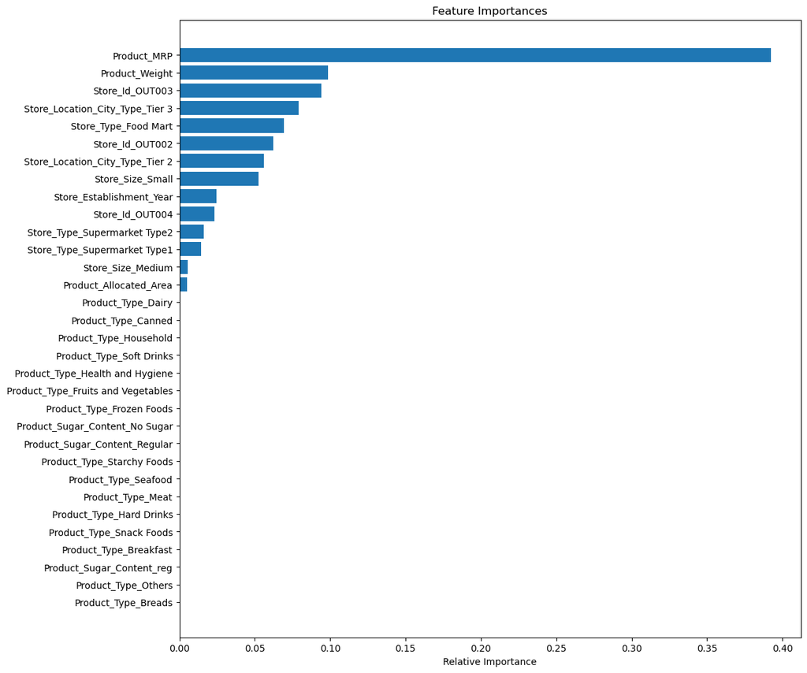

```python
feature_names=x_train.columns
importances = rf_tuned.feature_importances_
indices=np.argsort(importances)

plt.figure(figsize=(12,12))
plt.title("Feature Importances")
plt.barh(range(len(indices)), importances[indices])
plt.yticks(range(len(indices)), [feature_names[i] for i in indices])
plt.xlabel("Relative Importance")
plt.show()
```

- the retail price and weight of the products have the highest importance in the random forest model

### Adaboost Tuning

```python
ab_tuned=AdaBoostRegressor(random_state=1)

#Grid of parameters to choose from
parameters= { "n_estimators": np.arange(10,100,10),
              "learning_rate": [1,0.1,0.5,0.01],
            }

#type of scoring used used to compare parameter combinations
scorer=metrics.make_scorer(metrics.r2_score)

#Run the grid search
grid_obj=GridSearchCV(ab_tuned,parameters,scoring=scorer,cv=5)
grid_obj=grid_obj.fit(x_train,Y_train)

#set clf to best combination of parameters
ab_tuned=grid_obj.best_estimator_

#Fit the best algorithm to the data
ab_tuned.fit(x_train,Y_train)
```

```
AdaBoostRegressor(learning_rate=0.01, n_estimators=30, random_state=1)
```

```python
ab_tuned_model_train_perf=model_performance_regression(ab_tuned,x_train,Y_train)
print("training performance \n", ab_tuned_model_train_perf)
```

```
training performance
          RMSE         MAE  R-squared  Adj. R-squared       MAPE
0  453.830429  349.308634   0.817973        0.817019  11.986296
```

```python
ab_tuned_model_test_perf=model_performance_regression(ab_tuned,x_train,Y_train)
print("testing performances \n", ab_tuned_model_test_perf)
```

```
testing performances
          RMSE         MAE  R-squared  Adj. R-squared       MAPE
0  453.830429  349.308634   0.817973        0.817019  11.986296
```

```python
print(pd.DataFrame(ab_tuned.feature_importances_,columns=["Imp"], index=x_train.columns).sort_values(by="Imp",ascending=False))
```

```
                                         Imp
Product_MRP                         0.349379
Store_Location_City_Type_Tier 2     0.143093
Store_Type_Food Mart                0.134025
Store_Size_Small                    0.100680
Store_Id_OUT002                     0.088852
Store_Id_OUT003                     0.070890
Store_Location_City_Type_Tier 3     0.057714
Store_Id_OUT004                     0.014295
Store_Type_Supermarket Type2        0.013750
Store_Type_Supermarket Type1        0.013267
Store_Establishment_Year            0.010534
Product_Weight                      0.003521
Product_Type_Fruits and Vegetables  0.000000
Product_Type_Hard Drinks            0.000000
Product_Sugar_Content_No Sugar      0.000000
Product_Sugar_Content_Regular       0.000000
Product_Sugar_Content_reg           0.000000
Product_Type_Breads                 0.000000
Product_Type_Breakfast              0.000000
Store_Size_Medium                   0.000000
Product_Type_Canned                 0.000000
Product_Type_Dairy                  0.000000
Product_Type_Frozen Foods           0.000000
Product_Type_Starchy Foods          0.000000
Product_Type_Soft Drinks            0.000000
Product_Type_Snack Foods            0.000000
Product_Type_Seafood                0.000000
Product_Type_Others                 0.000000
Product_Allocated_Area              0.000000
Product_Type_Household              0.000000
Product_Type_Health and Hygiene     0.000000
Product_Type_Meat                   0.000000
```

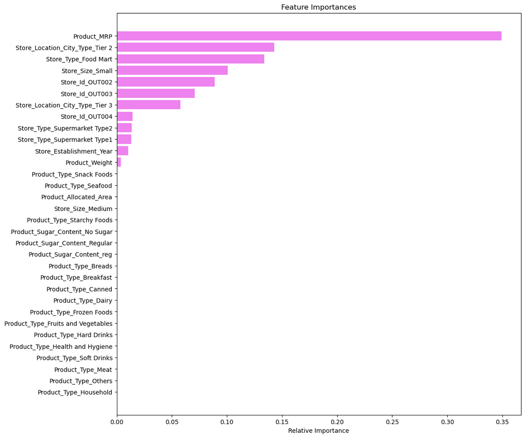

```python
feature_names=x_train.columns
importances=ab_tuned.feature_importances_
indices=np.argsort(importances)

plt.figure(figsize=(12,12))
plt.title("Feature Importances")
plt.barh(range(len(indices)),importances[indices],color="violet",align="center")
plt.yticks(range(len(indices)),[feature_names[i] for i in indices])
plt.xlabel("Relative Importance")
plt.show()
```

- The retail price of the product and city type 2 have the highest importance in terms of the adaboost regressor

### gradientboost tuning

```python
gb_tuned=GradientBoostingRegressor(random_state=1)

#Grid of parameters to choose from
parameters={"n_estimators": np.arange(50,200,25),
            "subsample":[0.7,0.8,0.9,1],
            "max_features":[0.7,0.8,0.9,1],
            "max_depth":[3.5,7,10]
           }

#type of scoring used to compare parameter combinations
scorer=metrics.make_scorer(metrics.r2_score)

#Run the grid search
grid_obj=GridSearchCV(gb_tuned,parameters,scoring=scorer,cv=5)
grid_obj=grid_obj.fit(x_train,Y_train)

#setting the clf to the best combination of parameters
gb_tuned=grid_obj.best_estimator_

#fit the bst algorithm to the data
gb_tuned.fit(x_train,Y_train)
```

```
GradientBoostingRegressor(max_depth=7, max_features=0.7, n_estimators=50,
                          random_state=1, subsample=0.9)
```

```python
gb_tuned_model_train_perf=model_performance_regression(gb_tuned,x_train,Y_train)
print("Training performance \n",gb_tuned_model_train_perf)
```

```
Training performance
          RMSE        MAE  R-squared  Adj. R-squared      MAPE
0  177.891155  71.868852   0.972032        0.971886  2.370693
```

```python
gb_tuned_model_test_perf=model_performance_regression(gb_tuned,x_test,Y_test)
print("Testing Performance \n",gb_tuned_model_test_perf)
```

```
Testing Performance
          RMSE         MAE  R-squared  Adj. R-squared      MAPE
0  292.237526  116.788576    0.92537         0.92445  5.140532
```

- Training performance has increased by 5 percent while testing increased by 2 percent
- model still overfit after tuning

```python
#important features
print(pd.DataFrame(gb_tuned.feature_importances_,columns=["Imp"],index=x_train.columns).sort_values(by="Imp",ascending=False))
```

```
                                         Imp
Product_MRP                         0.427992
Store_Location_City_Type_Tier 3     0.148519
Store_Id_OUT003                     0.114195
Product_Weight                      0.108343
Store_Type_Food Mart                0.045756
Store_Id_OUT002                     0.036286
Store_Id_OUT004                     0.034786
Store_Establishment_Year            0.028443
Store_Location_City_Type_Tier 2     0.016811
Store_Type_Supermarket Type1        0.012249
Store_Type_Supermarket Type2        0.008144
Product_Allocated_Area              0.005173
Store_Size_Small                    0.003955
Store_Size_Medium                   0.002275
Product_Sugar_Content_Regular       0.000963
Product_Type_Dairy                  0.000803
Product_Type_Canned                 0.000798
Product_Sugar_Content_No Sugar      0.000640
Product_Type_Health and Hygiene     0.000606
Product_Type_Fruits and Vegetables  0.000504
Product_Type_Household              0.000503
Product_Type_Soft Drinks            0.000445
Product_Type_Starchy Foods          0.000350
Product_Type_Meat                   0.000347
Product_Type_Seafood                0.000279
Product_Type_Frozen Foods           0.000189
Product_Type_Breakfast              0.000183
Product_Type_Hard Drinks            0.000159
Product_Type_Snack Foods            0.000148
Product_Sugar_Content_reg           0.000066
Product_Type_Others                 0.000050
Product_Type_Breads                 0.000037
```

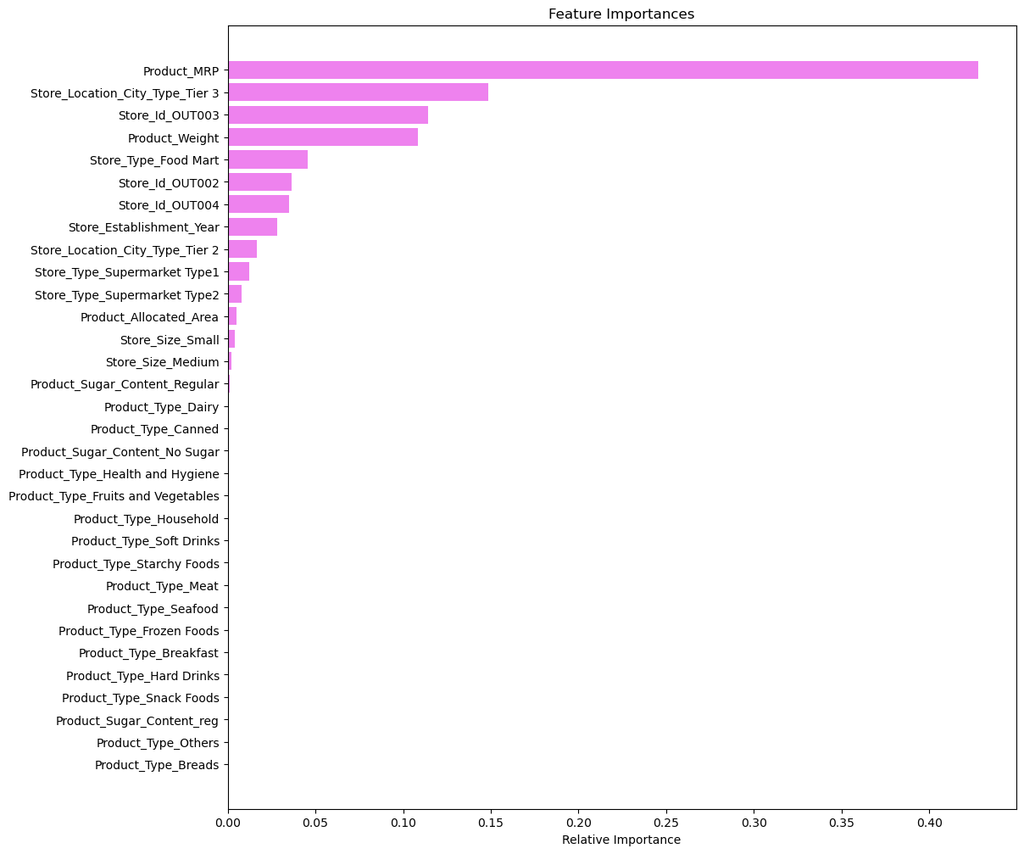

```python
feature_names=x_train.columns
importances=gb_tuned.feature_importances_
indices=np.argsort(importances)

plt.figure(figsize=(12,12))
plt.title("Feature Importances")
plt.barh(range(len(indices)),importances[indices],color="violet",align="center")
plt.yticks(range(len(indices)), [feature_names[i] for i in indices])
plt.xlabel('Relative Importance')
plt.show()
```

- the retail price of the product and the city type 3 variable hold the most importance when it comes to the gradient boosting model

### xgboost regressor

```python
xgb_tuned=XGBRegressor(random_state=1,verbosity=0)

#Grid of pararmeters to choose from
parameters={"n-estimators":[75,100,125,150],
            "subsample":[0.7,0.8,0.9,1],
            "gamma":[0,1,3,5],
            "colsample_bytree":[0.7,0.8,0.9,1],
            "colsample_bylevel":[0.7,0.8,0.9,1]
            }

#type of scoring used to compare parameter combinations
scorer=metrics.make_scorer(metrics.r2_score)

#Run the grid search
grid_obj=GridSearchCV(xgb_tuned, parameters, scoring=scorer, cv=5)
grid_obj=grid_obj.fit(x_train,Y_train)

#set up clf to the best combination of parameters
xgb_tuned=grid_obj.best_estimator_

#Fit the best algorithm to the data
xgb_tuned.fit(x_train, Y_train)
```

```
XGBRegressor(base_score=None, booster=None, callbacks=None,
             colsample_bylevel=0.7, colsample_bynode=None, colsample_bytree=0.8,
             device=None, early_stopping_rounds=None, enable_categorical=False,
             eval_metric=None, feature_types=None, gamma=0, grow_policy=None,
             importance_type=None, interaction_constraints=None,
             learning_rate=None, max_bin=None, max_cat_threshold=None,
             max_cat_to_onehot=None, max_delta_step=None, max_depth=None,
             max_leaves=None, min_child_weight=None, missing=nan,
             monotone_constraints=None, multi_strategy=None, n-estimators=75,
             n_estimators=None, n_jobs=None, num_parallel_tree=None, ...)
```

```python
xgb_tuned_model_train_perf= model_performance_regression(xgb_tuned, x_train, Y_train)
print("training performance \n", xgb_tuned_model_train_perf)
```

```
training performance
          RMSE        MAE  R-squared  Adj. R-squared      MAPE
0  132.086453  67.717411   0.984581          0.9845  2.319997
```

```python
xgb_tuned_model_test_perf=model_performance_regression(xgb_tuned, x_test, Y_test)
print("Testsing performance \n", xgb_tuned_model_test_perf)
```

```
Testsing performance
          RMSE         MAE  R-squared  Adj. R-squared      MAPE
0  311.645248  141.469202   0.915129        0.914082  5.633975
```

- not a significant change after tuning, model still has the same performance scores

```python
#feature importances
print(pd.DataFrame(xgb_tuned.feature_importances_, columns=["Imp"], index= x_train.columns).sort_values(by = "Imp", ascending=False))
```

```
                                         Imp
Store_Id_OUT002                     0.573824
Store_Id_OUT003                     0.178274
Store_Type_Supermarket Type1        0.090623
Store_Size_Small                    0.045516
Store_Location_City_Type_Tier 2     0.027480
Product_MRP                         0.025600
Store_Size_Medium                   0.010173
Product_Weight                      0.010168
Store_Id_OUT004                     0.005948
Store_Establishment_Year            0.004252
Product_Type_Dairy                  0.002308
Store_Location_City_Type_Tier 3     0.001949
Product_Type_Hard Drinks            0.001941
Product_Type_Household              0.001888
Product_Type_Seafood                0.001837
Product_Allocated_Area              0.001628
Product_Type_Canned                 0.001593
Product_Type_Health and Hygiene     0.001579
Product_Type_Frozen Foods           0.001371
Product_Type_Soft Drinks            0.001286
Product_Type_Fruits and Vegetables  0.001197
Product_Type_Snack Foods            0.001135
Product_Sugar_Content_Regular       0.001134
Product_Type_Meat                   0.001084
Product_Sugar_Content_No Sugar      0.001067
Store_Type_Food Mart                0.001049
Product_Type_Starchy Foods          0.000934
Product_Type_Breakfast              0.000795
Product_Type_Others                 0.000770
Product_Sugar_Content_reg           0.000709
Product_Type_Breads                 0.000472
Store_Type_Supermarket Type2        0.000417
```

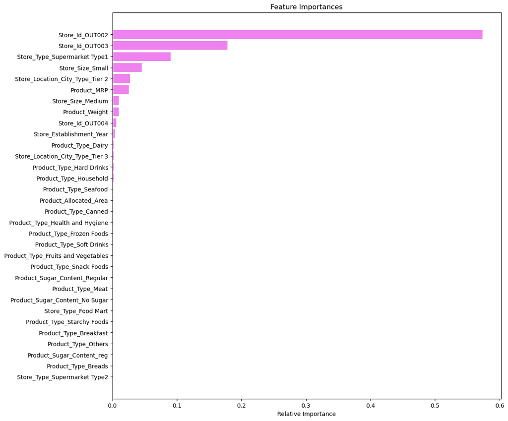

```python
feature_names= x_train.columns
importances = xgb_tuned.feature_importances_
indices=np.argsort(importances)

plt.figure(figsize=(12,12))
plt.title("Feature Importances")
plt.barh(range(len(indices)), importances[indices],color="violet",align="center")
plt.yticks(range(len(indices)), [feature_names[i] for i in indices])
plt.xlabel("Relative Importance")
plt.show()
```

## Stacking Model

```python
estimators=[("Decision Tree",dtree_tuned),('Random Forest',rf_tuned),("Gradient Boosting", gb_tuned)]
final_estimator=XGBRegressor(random_state=1)
```

```python
stacking_estimator=StackingRegressor(estimators=estimators, final_estimator=final_estimator,cv=5)
stacking_estimator.fit(x_train,Y_train)
```

```
StackingRegressor(cv=5,
                  estimators=[('Decision Tree',
                               DecisionTreeRegressor(max_depth=9,
                                                     min_impurity_decrease=0.001,
                                                     min_samples_leaf=7,
                                                     random_state=1)),
                              ('Random Forest',
                               RandomForestRegressor(max_depth=10,
                                                     max_features=None,
                                                     n_estimators=120,
                                                     random_state=1)),
                              ('Gradient Boosting',
                               GradientBoostingRegressor(max_depth=7,
                                                         max_features=0.7,
                                                         n_estimators=50,
                                                         random_...
                                               feature_types=None, gamma=None,
                                               grow_policy=None,
                                               importance_type=None,
                                               interaction_constraints=None,
                                               learning_rate=None, max_bin=None,
                                               max_cat_threshold=None,
                                               max_cat_to_onehot=None,
                                               max_delta_step=None,
                                               max_depth=None, max_leaves=None,
                                               min_child_weight=None,
                                               missing=nan,
                                               monotone_constraints=None,
                                               multi_strategy=None,
                                               n_estimators=None, n_jobs=None,
                                               num_parallel_tree=None,
                                               random_state=1, ...))
```

```python
stacking_estimator_model_train_perf=model_performance_regression(stacking_estimator,x_train,Y_train)
print("training performance \n",stacking_estimator_model_train_perf)
```

[output not shown]

```python
stacking_estimator_model_test_perf=model_performance_regression(stacking_estimator,x_test,Y_test)
print("testing performance \n",stacking_estimator_model_test_perf)
```

```
testing performance
          RMSE         MAE  R-squared  Adj. R-squared      MAPE
0  310.765178  138.966362   0.915607        0.914567  5.574265
```

- slight overfit but model is performing well

## Model Performance Comparison and Conclusions

```python
#training performance comparison

models_train_comp_df=pd.concat([dtree_model_train_perf.T, dtree_tuned_model_train_perf.T,bagging_regressor_model_train_perf.T,bagging_regressor_tuned_train_model_perf.T,rf_estimator_model_train_perf.T,rf_tuned_model_train_perf.T,ab_regressor_model_train_perf.T,ab_tuned_model_train_perf.T,gb_estimator_model_train_perf.T,gb_tuned_model_train_perf.T,xgb_estimator_model_train_perf.T,xgb_tuned_model_train_perf.T,stacking_estimator_model_train_perf.T],axis=1,)

models_train_comp_df.columns=[
    "Decision Tree",
    "Decision Tree Tuned",
    "Bagging Regressor",
    "tuned Bagging Regressor",
    "Random Forest Estimator",
    "Random Forest Tuned",
    "Adaboost Regressor",
    "Adaboost Tuned",
    "Gradient Boost Estimator",
    "Gradient Boost Tuned",
    "XGB",
    "XGB Tuned",
    "Stacking Regressor"
]

print("training performance comparison:")
models_train_comp_df
```

```
training performance comparison:
```

|  | Decision Tree | Decision Tree Tuned | Bagging Regressor | tuned Bagging Regressor | Random Forest Estimator | Random Forest Tuned | Adaboost Regressor | Adaboost Tuned | Gradient Boost Estimator | Gradient Boost Tuned | XGB | XGB Tuned | Stacking Regressor |
| --- | --- | --- | --- | --- | --- | --- | --- | --- | --- | --- | --- | --- | --- |
| RMSE | 0.0 | 258.229224 | 118.635758 | 147.647087 | 103.579909 | 182.444629 | 518.669096 | 453.830429 | 291.490433 | 177.891155 | 116.120060 | 132.086453 | 209.084639 |
| MAE | 0.0 | 122.736094 | 44.811827 | 78.397256 | 39.468334 | 75.097417 | 415.459639 | 349.308634 | 141.389962 | 71.868852 | 57.210877 | 67.717411 | 96.859796 |
| R-squared | 1.0 | 0.941067 | 0.987561 | 0.980734 | 0.990518 | 0.970582 | 0.762246 | 0.817973 | 0.924908 | 0.972032 | 0.988083 | 0.984581 | 0.961364 |
| Adj. R-squared | 1.0 | 0.940758 | 0.987496 | 0.980633 | 0.990468 | 0.970428 | 0.760999 | 0.817019 | 0.924514 | 0.971886 | 0.988021 | 0.984500 | 0.961161 |
| MAPE | 0.0 | 4.217715 | 1.608650 | 2.793973 | 1.394348 | 2.512823 | 14.083721 | 11.986296 | 5.084413 | 2.370693 | 1.932520 | 2.319997 | 3.308596 |

```python
models_test_comp_df=pd.concat([dtree_model_test_perf.T, dtree_tuned_model_test_perf.T,bagging_regressor_model_test_perf.T,bagging_regressor_tuned_test_model_perf.T,rf_estimator_model_test_perf.T,rf_tuned_model_test_perf.T,ab_regressor_model_test_perf.T,ab_tuned_model_test_perf.T,gb_estimator_model_test_perf.T,gb_tuned_model_test_perf.T,xgb_estimator_model_test_perf.T,xgb_tuned_model_test_perf.T,stacking_estimator_model_test_perf.T],axis=1,)

models_test_comp_df.columns=[
    "Decision Tree",
    "Decision Tree Tuned",
    "Bagging Regressor",
    "tuned Bagging Regressor",
    "Random Forest Estimator",
    "Random Forest Tuned",
    "Adaboost Regressor",
    "Adaboost Tuned",
    "Gradient Boost Estimator",
    "Gradient Boost Tuned",
    "XGB",
    "XGB Tuned",
    "Stacking Regressor"
]

print("testing performance comparison:")
models_test_comp_df
```

```
testing performance comparison:
```

|  | Decision Tree | Decision Tree Tuned | Bagging Regressor | tuned Bagging Regressor | Random Forest Estimator | Random Forest Tuned | Adaboost Regressor | Adaboost Tuned | Gradient Boost Estimator | Gradient Boost Tuned | XGB | XGB Tuned | Stacking Regressor |
| --- | --- | --- | --- | --- | --- | --- | --- | --- | --- | --- | --- | --- | --- |
| RMSE | 380.764206 | 310.006452 | 307.062513 | 308.178734 | 294.485128 | 292.545023 | 538.310826 | 453.830429 | 322.284130 | 292.237526 | 310.592446 | 311.645248 | 310.765178 |
| MAE | 129.898505 | 146.768554 | 119.273693 | 160.786777 | 111.512945 | 116.683457 | 431.469130 | 349.308634 | 155.544186 | 116.788576 | 138.111121 | 141.469202 | 138.966362 |
| R-squared | 0.873307 | 0.916019 | 0.917606 | 0.917006 | 0.924218 | 0.925213 | 0.746775 | 0.817973 | 0.909235 | 0.925370 | 0.915701 | 0.915129 | 0.915607 |
| Adj. R-squared | 0.871745 | 0.914984 | 0.916591 | 0.915983 | 0.923284 | 0.924291 | 0.743654 | 0.817019 | 0.908116 | 0.924450 | 0.914662 | 0.914082 | 0.914567 |
| MAPE | 5.560926 | 6.355626 | 5.086928 | 6.858755 | 4.991390 | 5.220086 | 16.478161 | 11.986296 | 6.624532 | 5.140532 | 5.631813 | 5.633975 | 5.574265 |

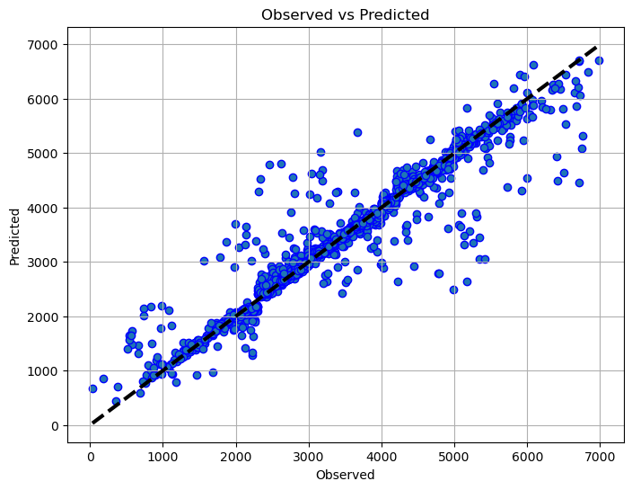

```python
fig,ax=plt.subplots(figsize=(8,6))
Y_pred=gb_tuned.predict(x_test)
ax.scatter(Y_test, Y_pred, edgecolors=(0,0,1))
ax.plot([Y_test.min(),Y_test.max()],[Y_test.min(),Y_test.max()], "k--", lw=3)
ax.set_xlabel("Observed")
ax.set_ylabel("Predicted")
ax.set_title("Observed vs Predicted")
plt.grid()
plt.show()
```

- There were a few points that didn't fit the line, but most of the points fit the line and therefore the model has performance despite some overfitting issues that are still happening

## Actionable Insights and Recommendations

- City tier 3 shows high importance, so opening more stores there would have a positive impact on the sales
- The retail price of the product also plays a huge role, and from the eda we have conducted, high piced products usually lead to higher sales of the product so increasing the price might be in the company's best benefit